# R Notebook

# Business understanding

Carrefour is a French multinational corporation that specializes in retail.It operates in many countries including UAE,Autralia,Brazil and closer home,Kenya,among many others.

Carrefour is located in 7 major areas in Kenya.

# Business understanding

You are a Data analyst at Carrefour Kenya and are currently undertaking a project that will inform the marketing department on the most relevant marketing strategies that will result in the highest no. of sales (total price including tax).

# Experimental design

Your project has been divided into four parts where you’ll explore a recent marketing dataset by performing various unsupervised learning techniques and later providing recommendations based on your insights.

Part 1: Dimensionality Reduction

This section of the project entails reducing your dataset to a low dimensional dataset using the t-SNE algorithm or PCA. You will be required to perform your analysis and provide insights gained from your analysis.

Part 2: Feature Selection

This section requires you to perform feature selection through the use of the unsupervised learning methods learned earlier this week. You will be required to perform your analysis and provide insights on the features that contribute the most information to the dataset.

Part 3: Association Rules

This section will require that you create association rules that will allow you to identify relationships between variables in the dataset. You are provided with a separate dataset that comprises groups of items that will be associated with others. Just like in the other sections, you will also be required to provide insights for your analysis.

Part 4: Anomaly Detection

You have also been requested to check whether there are any anomalies in the given sales dataset. The objective of this task being fraud detection.

# Assessing the situation at hand

## Resources inventory

### Datasets

The datasets can be sourced from the following sites 1.) https://archive.org/download/supermarketdataset1salesdata/Supermarket_Dataset_1%20-%20Sales%20Data.csv

2.) https://archive.org/download/supermarketsalesdatasetii/Supermarket_Sales_Dataset%20II.csv

3.) https://archive.org/download/supermarketsalesforecastingsales/Supermarket_Sales_Forecasting%20-%20Sales.csv

Software (Github,R)

# Assumptions

The data is up to date and relevant. # Constraints There are no constraints currently.

# Loading in our datasets

```r
library(readr)
sdf <- read_csv("Supermarket_Dataset_1 - Sales Data.csv")
View(sdf)
```

# Data understanding

Preview of the head of the dataset

```r
head(sdf,4)
```

[output not shown]

# Preview of tail of the dataset

```r
tail(sdf,4)
```

| Invoice ID | Branch | Customer type | Gender | Product line | Unit price | Quantity | Tax | Date | Time | Payment | cogs | gross margin percentage | gross income | Rating | Total |
| --- | --- | --- | --- | --- | --- | --- | --- | --- | --- | --- | --- | --- | --- | --- | --- |
| 303-96-2227 | B | Normal | Female | Home and lifestyle | 97.38 | 10 | 48.690 | 3/2/2019 | 62160 secs | Ewallet | 973.80 | 4.761905 | 48.690 | 4.4 | 1022.490 |
| 727-02-1313 | A | Member | Male | Food and beverages | 31.84 | 1 | 1.592 | 2/9/2019 | 48120 secs | Cash | 31.84 | 4.761905 | 1.592 | 7.7 | 33.432 |
| 347-56-2442 | A | Normal | Male | Home and lifestyle | 65.82 | 1 | 3.291 | 2/22/2019 | 55980 secs | Cash | 65.82 | 4.761905 | 3.291 | 4.1 | 69.111 |
| 849-09-3807 | A | Member | Female | Fashion accessories | 88.34 | 7 | 30.919 | 2/18/2019 | 48480 secs | Cash | 618.38 | 4.761905 | 30.919 | 6.6 | 649.299 |

No of columns and obsevations per variable

```r
dim(sdf)
```

```
[1] 1000   16
```

The dataset has 1000 observations of 16 variables

# Summary statistics about variables.

```r
library(skimr)
skim(sdf)
```

```
-- Data Summary ------------------------
                           Values
Name                       sdf
Number of rows             1000
Number of columns          16
_______________________
Column type frequency:
  character                7
  difftime                 1
  numeric                  8
________________________
Group variables            None

-- Variable type: character ---------------------------------------------------------------------
# A tibble: 7 x 8
  skim_variable n_missing complete_rate   min   max empty n_unique whitespace
* <chr>             <int>         <dbl> <int> <int> <int>    <int>      <int>
1 Invoice ID            0             1    11    11     0     1000          0
2 Branch                0             1     1     1     0        3          0
3 Customer type         0             1     6     6     0        2          0
4 Gender                0             1     4     6     0        2          0
5 Product line          0             1    17    22     0        6          0
6 Date                  0             1     8     9     0       89          0
7 Payment               0             1     4    11     0        3          0

-- Variable type: difftime ----------------------------------------------------------------------
# A tibble: 1 x 7
  skim_variable n_missing complete_rate min        max        median     n_unique
* <chr>             <int>         <dbl> <drtn>     <drtn>     <drtn>        <int>
1 Time                  0             1 36000 secs 75540 secs 55140 secs      506

-- Variable type: numeric -----------------------------------------------------------------------
# A tibble: 8 x 11
  skim_variable           n_missing complete_rate   mean     sd     p0    p25    p50    p75
* <chr>                       <int>         <dbl>  <dbl>  <dbl>  <dbl>  <dbl>  <dbl>  <dbl>
1 Unit price                      0             1  55.7   26.5  10.1    32.9   55.2   77.9
2 Quantity                        0             1   5.51   2.92  1       3      5      8
3 Tax                             0             1  15.4   11.7   0.508   5.92  12.1   22.4
4 cogs                            0             1 308.   234.   10.2   118.   242.   449.
5 gross margin percentage         0             1   4.76   0     4.76    4.76   4.76   4.76
6 gross income                    0             1  15.4   11.7   0.508   5.92  12.1   22.4
7 Rating                          0             1   6.97   1.72  4       5.5    7      8.5
8 Total                           0             1 323.   246.   10.7   124.   254.   471.
     p100 hist
*   <dbl> <chr>
1  100.   ▇▇▇▇▇
2   10    ▇▇▇▇▇
3   49.6  ▇▅▃▂▁
4  993    ▇▅▃▂▁
5    4.76 ▁▁▇▁▁
6   49.6  ▇▅▃▂▁
7   10    ▇▇▇▇▇
8 1043.   ▇▅▃▂▁
```

# Summary of variables

```r
names(sdf)
```

```
 [1] "Invoice ID"              "Branch"                  "Customer type"
 [4] "Gender"                  "Product line"            "Unit price"
 [7] "Quantity"                "Tax"                     "Date"
[10] "Time"                    "Payment"                 "cogs"
[13] "gross margin percentage" "gross income"            "Rating"
[16] "Total"
```

# Summary of their datatypes

```r
sapply(sdf,class)
```

```
$`Invoice ID`
[1] "character"

$Branch
[1] "character"

$`Customer type`
[1] "character"

$Gender
[1] "character"

$`Product line`
[1] "character"

$`Unit price`
[1] "numeric"

$Quantity
[1] "numeric"

$Tax
[1] "numeric"

$Date
[1] "character"

$Time
[1] "hms"      "difftime"

$Payment
[1] "character"

$cogs
[1] "numeric"

$`gross margin percentage`
[1] "numeric"

$`gross income`
[1] "numeric"

$Rating
[1] "numeric"

$Total
[1] "numeric"
```

# Data cleaning

```r
library(tidyverse)
```

## 1.Missing/Null values

```r
colSums(is.na(sdf))
```

```
             Invoice ID                  Branch
                      0                       0
          Customer type                  Gender
                      0                       0
           Product line              Unit price
                      0                       0
               Quantity                     Tax
                      0                       0
                   Date                    Time
                      0                       0
                Payment                    cogs
                      0                       0
gross margin percentage            gross income
                      0                       0
                 Rating                   Total
                      0                       0
```

From the above summary,we can see that thedataset has no missing values

## 2. Duplicates

```r
sdf_dd<- sdf[duplicated(sdf),]
dim(sdf_dd)
```

```
[1]  0 16
```

As we can see, our dataset has no duplicates

## 3. Check for data types

```r
str(sdf)
```

```
tibble [1,000 x 16] (S3: spec_tbl_df/tbl_df/tbl/data.frame)
 $ Invoice ID             : chr [1:1000] "750-67-8428" "226-31-3081" "631-41-3108" "123-19-1176" ...
 $ Branch                 : chr [1:1000] "A" "C" "A" "A" ...
 $ Customer type          : chr [1:1000] "Member" "Normal" "Normal" "Member" ...
 $ Gender                 : chr [1:1000] "Female" "Female" "Male" "Male" ...
 $ Product line           : chr [1:1000] "Health and beauty" "Electronic accessories" "Home and lifestyle" "Health and beauty" ...
 $ Unit price             : num [1:1000] 74.7 15.3 46.3 58.2 86.3 ...
 $ Quantity               : num [1:1000] 7 5 7 8 7 7 6 10 2 3 ...
 $ Tax                    : num [1:1000] 26.14 3.82 16.22 23.29 30.21 ...
 $ Date                   : chr [1:1000] "1/5/2019" "3/8/2019" "3/3/2019" "1/27/2019" ...
 $ Time                   : 'hms' num [1:1000] 13:08:00 10:29:00 13:23:00 20:33:00 ...
  ..- attr(*, "units")= chr "secs"
 $ Payment                : chr [1:1000] "Ewallet" "Cash" "Credit card" "Ewallet" ...
 $ cogs                   : num [1:1000] 522.8 76.4 324.3 465.8 604.2 ...
 $ gross margin percentage: num [1:1000] 4.76 4.76 4.76 4.76 4.76 ...
 $ gross income           : num [1:1000] 26.14 3.82 16.22 23.29 30.21 ...
 $ Rating                 : num [1:1000] 9.1 9.6 7.4 8.4 5.3 4.1 5.8 8 7.2 5.9 ...
 $ Total                  : num [1:1000] 549 80.2 340.5 489 634.4 ...
 - attr(*, "spec")=
  .. cols(
  ..   `Invoice ID` = col_character(),
  ..   Branch = col_character(),
  ..   `Customer type` = col_character(),
  ..   Gender = col_character(),
  ..   `Product line` = col_character(),
  ..   `Unit price` = col_double(),
  ..   Quantity = col_double(),
  ..   Tax = col_double(),
  ..   Date = col_character(),
  ..   Time = col_time(format = ""),
  ..   Payment = col_character(),
  ..   cogs = col_double(),
  ..   `gross margin percentage` = col_double(),
  ..   `gross income` = col_double(),
  ..   Rating = col_double(),
  ..   Total = col_double()
  .. )
```

## Correct some datatypes

During our check for datatypes,we noticed that some of the variables have been assigned the wrong datatype.We,therefore correct this. In this stage,we will also split the date column to our preferred format.

We change some of the columns with the character datatype to numerical datatype

```r
sdf$Branch <- as.integer(as.factor(sdf$Branch))
sdf$`Customer type` <- as.integer(as.factor(sdf$`Customer type`))
sdf$Gender <- as.integer(as.factor(sdf$Gender))
sdf$`Product line` <-as.integer(as.factor(sdf$`Product line`))
sdf$Payment <-as.integer(as.factor(sdf$Payment))
```

We then split the date & time column

```r
sdf$Date_Time =  strptime(paste(sdf$Date, sdf$Time), format="%m/%d/%Y %M:%S")
```

Let’s check our dataset once more

```r
str(sdf)
```

```
tibble [1,000 x 17] (S3: spec_tbl_df/tbl_df/tbl/data.frame)
 $ Invoice ID             : chr [1:1000] "750-67-8428" "226-31-3081" "631-41-3108" "123-19-1176" ...
 $ Branch                 : int [1:1000] 1 3 1 1 1 3 1 3 1 2 ...
 $ Customer type          : int [1:1000] 1 2 2 1 2 2 1 2 1 1 ...
 $ Gender                 : int [1:1000] 1 1 2 2 2 2 1 1 1 1 ...
 $ Product line           : int [1:1000] 4 1 5 4 6 1 1 5 4 3 ...
 $ Unit price             : num [1:1000] 74.7 15.3 46.3 58.2 86.3 ...
 $ Quantity               : num [1:1000] 7 5 7 8 7 7 6 10 2 3 ...
 $ Tax                    : num [1:1000] 26.14 3.82 16.22 23.29 30.21 ...
 $ Date                   : chr [1:1000] "1/5/2019" "3/8/2019" "3/3/2019" "1/27/2019" ...
 $ Time                   : 'hms' num [1:1000] 13:08:00 10:29:00 13:23:00 20:33:00 ...
  ..- attr(*, "units")= chr "secs"
 $ Payment                : int [1:1000] 3 1 2 3 3 3 3 3 2 2 ...
 $ cogs                   : num [1:1000] 522.8 76.4 324.3 465.8 604.2 ...
 $ gross margin percentage: num [1:1000] 4.76 4.76 4.76 4.76 4.76 ...
 $ gross income           : num [1:1000] 26.14 3.82 16.22 23.29 30.21 ...
 $ Rating                 : num [1:1000] 9.1 9.6 7.4 8.4 5.3 4.1 5.8 8 7.2 5.9 ...
 $ Total                  : num [1:1000] 549 80.2 340.5 489 634.4 ...
 $ Date_Time              : POSIXlt[1:1000], format: "2019-01-05 00:13:08" ...
 - attr(*, "spec")=
  .. cols(
  ..   `Invoice ID` = col_character(),
  ..   Branch = col_character(),
  ..   `Customer type` = col_character(),
  ..   Gender = col_character(),
  ..   `Product line` = col_character(),
  ..   `Unit price` = col_double(),
  ..   Quantity = col_double(),
  ..   Tax = col_double(),
  ..   Date = col_character(),
  ..   Time = col_time(format = ""),
  ..   Payment = col_character(),
  ..   cogs = col_double(),
  ..   `gross margin percentage` = col_double(),
  ..   `gross income` = col_double(),
  ..   Rating = col_double(),
  ..   Total = col_double()
  .. )
```

Remove the unnecesary columns

```r
sdf <- sdf[,c(-9,-10)]
names(sdf)
```

```
 [1] "Invoice ID"              "Branch"
 [3] "Customer type"           "Gender"
 [5] "Product line"            "Unit price"
 [7] "Quantity"                "Tax"
 [9] "Payment"                 "cogs"
[11] "gross margin percentage" "gross income"
[13] "Rating"                  "Total"
[15] "Date_Time"
```

## 4. Check for outliers

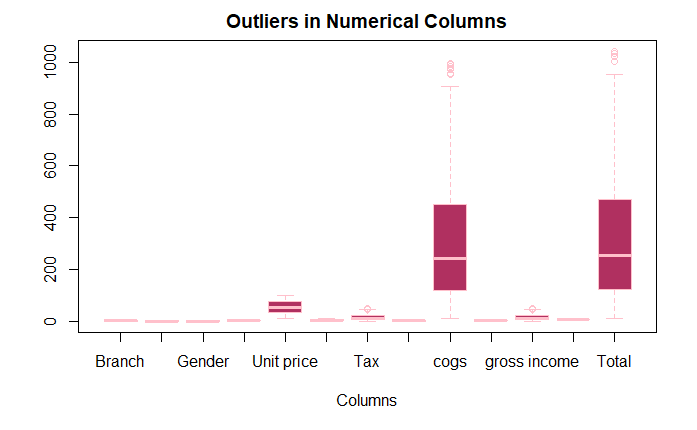

```r
num <- select_if(sdf, is.numeric)# Select numerical columns only
boxplot(num,
main = "Outliers in Numerical Columns",
xlab = "Columns",
col = "maroon",
border = "pink")
```

# Correlations

```r
data.num <- sdf[, sapply(sdf, is.numeric)]
data.cor = cor(data.num)
```

```
the standard deviation is zero
```

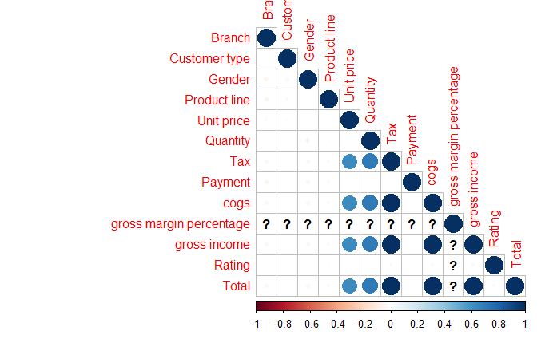

```r
library(corrplot)
corrplot(data.cor, type = 'lower')
```

# Principal Component Analysis

Principal component analysis (PCA) is a method to project data in a higher dimensional space into a lower dimensional space by maximizing the variance of each dimension.

PCA is applied to numerical values only

## Select numeric columns

```r
# select numeric columns
# Importing the library dplyr
library(dplyr)
super_num <- select_if(sdf, is.numeric)
```

## Dropping unnecessary

```r
super_num = super_num[,c(-4,-5,-10)]
names(super_num)
```

[output not shown]

```r
super_num.pca <- prcomp(super_num, center = TRUE, scale. = T)
summary(super_num.pca)
```

```
Importance of components:
                          PC1    PC2    PC3    PC4    PC5       PC6       PC7       PC8
Standard deviation     2.0016 1.0548 0.9947 0.9761 0.9690 3.178e-16 1.472e-16 1.198e-16
Proportion of Variance 0.5008 0.1391 0.1237 0.1191 0.1174 0.000e+00 0.000e+00 0.000e+00
Cumulative Proportion  0.5008 0.6399 0.7635 0.8826 1.0000 1.000e+00 1.000e+00 1.000e+00
```

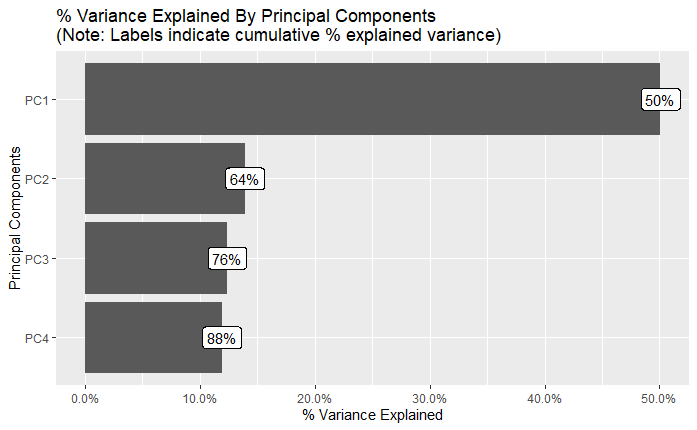

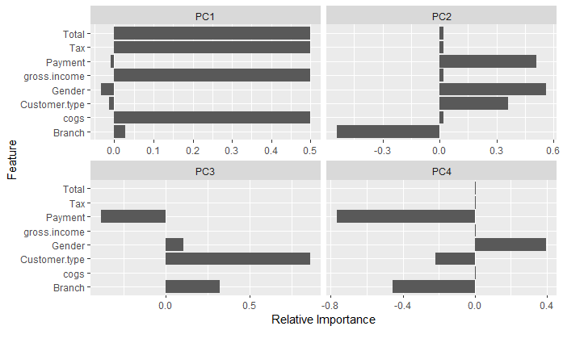

```r
library(DataExplorer)
plot_prcomp(super_num, variance_cap = 0.9, nrow = 2L, ncol = 2L)
```

Each explain a percentate of the total variation of the dataset’